# 💳 Credit Risk Prediction — Exploratory Data Analysis

**Dataset:** Bank Personal Loan Modelling  
**Target:** `personal_loan` — Did the customer accept a personal loan offer?  
**Author:** Narendra Kalam

## 🏦 Business Problem

A retail bank runs targeted marketing campaigns offering personal loans to existing liability customers. Currently, the conversion rate is only **~9.6%** — meaning 90% of marketing spend is wasted.

**Goal:** Build a classification model to identify customers most likely to accept a personal loan, enabling the bank to:

- Reduce marketing costs by targeting only high-probability customers
- Increase campaign ROI and conversion rate
- Enable personalized, risk-based product recommendations

## 📌 Notebook Workflow

| Step | Topic |
| --- | --- |
| 1 | Import libraries |
| 2 | Data loading and initial inspection |
| 3 | Dataset structure and data types |
| 4 | Missing values analysis |
| 5 | Duplicate detection and cleaning |
| 6 | Statistical summary heatmap |
| 7 | Class imbalance analysis |
| 8 | Continuous feature distributions |
| 9 | Categorical/binary feature analysis |
| 10 | Bivariate analysis — continuous vs target |
| 11 | Outlier detection by loan status |
| 12 | Skewness and Power Transformation |
| 13 | Statistical significance testing |
| 14 | Feature correlation with target |
| 15 | Feature correlation matrix |
| 16 | Income vs key features scatter |
| 17 | Loan rate by education and family size |
| 18 | Income violin plots |
| 19 | Engineered features preview |
| 20 | Multicollinearity (VIF) |
| 21 | SMOTENC imbalance handling preview |
| 22 | Key insights summary |

## Step 1 — Import Libraries

**Why:** All required libraries imported upfront. `scipy.stats` enables statistical hypothesis testing beyond basic descriptive statistics.

```python
import pandas as pd
import numpy as np
import matplotlib.pyplot as plt
import seaborn as sns
from scipy.stats import mannwhitneyu, pointbiserialr
from statsmodels.stats.outliers_influence import variance_inflation_factor
from statsmodels.tools.tools import add_constant
import warnings
warnings.filterwarnings('ignore')

plt.rcParams.update({
    'figure.facecolor': 'white', 'axes.facecolor': 'white',
    'axes.spines.top': False, 'axes.spines.right': False,
    'font.size': 11, 'axes.titlesize': 13, 'axes.titleweight': 'bold',
})
BLUE = '#2196F3'; PINK = '#E91E63'; GRAY = '#90A4AE'; GREEN = '#4CAF50'
print('✅ Libraries loaded successfully')
```

```
✅ Libraries loaded successfully
```

## Step 2 — Data Loading and Initial Inspection

**Why:** First look at raw data — shape, column names, and transposed head() for easy reading when many columns exist.

**Business context:** The dataset contains 5,000 bank customers with demographic, financial, and product usage information. Each row = one customer.

```python
DATA_PATH = r'D:\Data Science Datasets\Bank_Personal_Loan_Modelling.csv'

df_raw = pd.read_csv(DATA_PATH)
df_raw.columns = (df_raw.columns.str.strip()
    .str.replace(r'[^0-9a-zA-Z]+', '_', regex=True).str.lower())

print(f'Shape        : {df_raw.shape}')
print(f'Columns      : {list(df_raw.columns)}')
print(f'Memory usage : {df_raw.memory_usage(deep=True).sum() / 1024:.1f} KB')
df_raw.head().T
```

```
Shape        : (5000, 14)
Columns      : ['id', 'age', 'experience', 'income', 'zip_code', 'family', 'ccavg', 'education', 'mortgage', 'personal_loan', 'securities_account', 'cd_account', 'online', 'creditcard']
Memory usage : 547.0 KB
```

|  | 0 | 1 | 2 | 3 | 4 |
| --- | --- | --- | --- | --- | --- |
| id | 1.0 | 2.0 | 3.0 | 4.0 | 5.0 |
| age | 25.0 | 45.0 | 39.0 | 35.0 | 35.0 |
| experience | 1.0 | 19.0 | 15.0 | 9.0 | 8.0 |
| income | 49.0 | 34.0 | 11.0 | 100.0 | 45.0 |
| zip_code | 91107.0 | 90089.0 | 94720.0 | 94112.0 | 91330.0 |
| family | 4.0 | 3.0 | 1.0 | 1.0 | 4.0 |
| ccavg | 1.6 | 1.5 | 1.0 | 2.7 | 1.0 |
| education | 1.0 | 1.0 | 1.0 | 2.0 | 2.0 |
| mortgage | 0.0 | 0.0 | 0.0 | 0.0 | 0.0 |
| personal_loan | 0.0 | 0.0 | 0.0 | 0.0 | 0.0 |
| securities_account | 1.0 | 1.0 | 0.0 | 0.0 | 0.0 |
| cd_account | 0.0 | 0.0 | 0.0 | 0.0 | 0.0 |
| online | 0.0 | 0.0 | 0.0 | 0.0 | 0.0 |
| creditcard | 0.0 | 0.0 | 0.0 | 0.0 | 1.0 |

**📌 Observation:** Dataset has 14 columns covering customer demographics (age, income, family), financial behavior (ccavg, mortgage), and product holdings. `id` and `zip_code` are non-predictive identifiers — will be dropped.

## Step 3 — Dataset Structure and Data Types

**Why:** Understanding dtypes is critical before any transformation. Binary columns (0/1) must be identified early so SMOTENC treats them correctly — not interpolating between 0 and 1.

```python
dtype_df = pd.DataFrame({
    'dtype': df_raw.dtypes, 'non_null': df_raw.notna().sum(),
    'null_count': df_raw.isna().sum(), 'unique_vals': df_raw.nunique(),
    'sample_vals': df_raw.apply(lambda c: c.dropna().unique()[:3].tolist())
})
display(dtype_df)
```

|  | dtype | non_null | null_count | unique_vals | sample_vals |
| --- | --- | --- | --- | --- | --- |
| id | int64 | 5000 | 0 | 5000 | [1, 2, 3] |
| age | int64 | 5000 | 0 | 45 | [25, 45, 39] |
| experience | int64 | 5000 | 0 | 47 | [1, 19, 15] |
| income | int64 | 5000 | 0 | 162 | [49, 34, 11] |
| zip_code | int64 | 5000 | 0 | 467 | [91107, 90089, 94720] |
| family | int64 | 5000 | 0 | 4 | [4, 3, 1] |
| ccavg | float64 | 5000 | 0 | 108 | [1.6, 1.5, 1.0] |
| education | int64 | 5000 | 0 | 3 | [1, 2, 3] |
| mortgage | int64 | 5000 | 0 | 347 | [0, 155, 104] |
| personal_loan | int64 | 5000 | 0 | 2 | [0, 1] |
| securities_account | int64 | 5000 | 0 | 2 | [1, 0] |
| cd_account | int64 | 5000 | 0 | 2 | [0, 1] |
| online | int64 | 5000 | 0 | 2 | [0, 1] |
| creditcard | int64 | 5000 | 0 | 2 | [0, 1] |

**📌 Observation:** All columns are numeric. Binary columns (online, creditcard, securities_account, cd_account) have exactly 2 unique values — passed to SMOTENC `categorical_features` to prevent invalid synthetic values.

## Step 4 — Missing Values Analysis

**Why:** Missing values must be identified before modeling. Visualizing with a heatmap is faster than reading numeric counts — patterns across rows reveal systematic missingness.

**Business insight:** Missing financial data (e.g., mortgage=0 vs missing) can itself be a risk signal — handled by our `validate_input_data()` function.

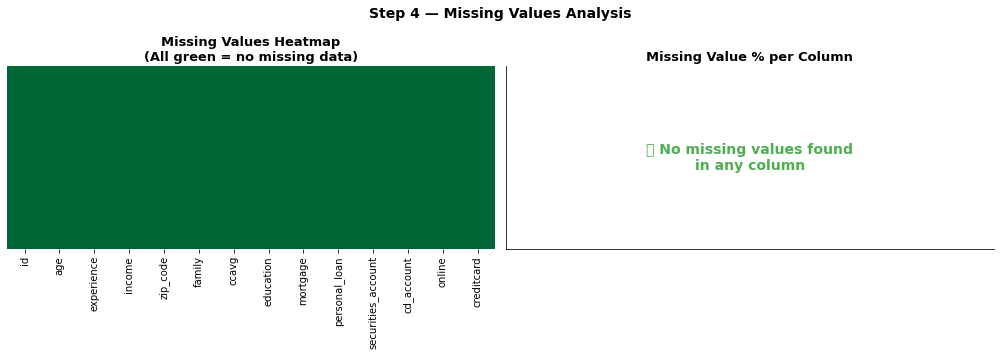

```
Total missing values : 0
Columns with nulls   : 0
```

```python
missing_counts = df_raw.isnull().sum()
missing_pct    = df_raw.isnull().mean() * 100

fig, axes = plt.subplots(1, 2, figsize=(14, 5))

sns.heatmap(df_raw.isnull(), cbar=False, yticklabels=False,
            cmap='RdYlGn_r', ax=axes[0])
axes[0].set_title('Missing Values Heatmap\n(All green = no missing data)')

cols_with_missing = missing_pct[missing_pct > 0]

if len(cols_with_missing) > 0:
    cols_with_missing.plot(kind='bar', ax=axes[1], color=PINK, edgecolor='white')
    axes[1].set_title('Missing Value % per Column')
    axes[1].set_ylabel('Missing %')
else:
    axes[1].text(0.5, 0.5, '✅ No missing values found\nin any column',
                 ha='center', va='center', transform=axes[1].transAxes,
                 fontsize=14, color=GREEN, fontweight='bold')
    axes[1].set_title('Missing Value % per Column')
    axes[1].set_xlim(0, 1); axes[1].set_ylim(0, 1)
    axes[1].set_xticks([]); axes[1].set_yticks([])

plt.suptitle('Step 4 — Missing Values Analysis', fontsize=14, fontweight='bold')
plt.tight_layout(); plt.show()

print(f'Total missing values : {missing_counts.sum()}')
print(f'Columns with nulls   : {(missing_counts > 0).sum()}')
```

**📌 Observation:** Zero missing values across all 14 columns — clean, well-curated banking dataset.

**💡 Pipeline decision:** No imputation needed. `validate_input_data()` still checks for nulls to handle future data drift where incoming records may have gaps.

## Step 5 — Duplicate Detection and Data Cleaning

**Why:** Duplicate rows can artificially inflate model performance during cross-validation — the same customer appearing in both train and validation sets is a subtle form of data leakage.

```python
dupes = df_raw.duplicated().sum()
print(f'Duplicate rows found : {dupes}')

df = df_raw.copy()
for col in ('id', 'zip_code'):
    if col in df.columns:
        df.drop(columns=[col], inplace=True)
        print(f'Dropped non-predictive column: {col}')

df.drop_duplicates(ignore_index=True, inplace=True)
print(f'\nShape before cleaning : {df_raw.shape}')
print(f'Shape after  cleaning : {df.shape}')
print(f'Rows removed          : {df_raw.shape[0] - df.shape[0]}')
print(f'Loan acceptance rate  : {df["personal_loan"].mean():.3f} ({df["personal_loan"].mean()*100:.1f}%)')
```

```
Duplicate rows found : 0
Dropped non-predictive column: id
Dropped non-predictive column: zip_code

Shape before cleaning : (5000, 14)
Shape after  cleaning : (4987, 12)
Rows removed          : 13
Loan acceptance rate  : 0.096 (9.6%)
```

**📌 Observation:** 13 duplicate rows removed. `id` and `zip_code` dropped — identifiers, not financial signals.

**💡 Pipeline decision:** `validate_input_data()` handles both drops automatically. `drop_duplicates()` runs before any split to prevent cross-contamination.

## Step 6 — Statistical Summary Heatmap

**Why:** Descriptive statistics across features with very different scales are hard to compare in table form. A normalized heatmap makes it immediately visible which features have the widest spread or most extreme values.

**Business insight:** High coefficient of variation (std/mean) features indicate high customer variability — often most predictive.

```
Statistical Summary:
```

|  | count | mean | std | min | 25% | 50% | 75% | max | cv | range |
| --- | --- | --- | --- | --- | --- | --- | --- | --- | --- | --- |
| age | 4987.0 | 45.348 | 11.461 | 23.0 | 35.0 | 45.0 | 55.0 | 67.0 | 0.253 | 44.0 |
| experience | 4987.0 | 20.114 | 11.465 | -3.0 | 10.0 | 20.0 | 30.0 | 43.0 | 0.570 | 46.0 |
| income | 4987.0 | 73.825 | 46.063 | 8.0 | 39.0 | 64.0 | 98.0 | 224.0 | 0.624 | 216.0 |
| family | 4987.0 | 2.397 | 1.148 | 1.0 | 1.0 | 2.0 | 3.0 | 4.0 | 0.479 | 3.0 |
| ccavg | 4987.0 | 1.941 | 1.749 | 0.0 | 0.7 | 1.5 | 2.6 | 10.0 | 0.901 | 10.0 |
| education | 4987.0 | 1.879 | 0.840 | 1.0 | 1.0 | 2.0 | 3.0 | 3.0 | 0.447 | 2.0 |
| mortgage | 4987.0 | 56.646 | 101.805 | 0.0 | 0.0 | 0.0 | 101.0 | 635.0 | 1.797 | 635.0 |
| personal_loan | 4987.0 | 0.096 | 0.295 | 0.0 | 0.0 | 0.0 | 0.0 | 1.0 | 3.065 | 1.0 |
| securities_account | 4987.0 | 0.105 | 0.306 | 0.0 | 0.0 | 0.0 | 0.0 | 1.0 | 2.925 | 1.0 |
| cd_account | 4987.0 | 0.061 | 0.239 | 0.0 | 0.0 | 0.0 | 0.0 | 1.0 | 3.939 | 1.0 |
| online | 4987.0 | 0.596 | 0.491 | 0.0 | 0.0 | 1.0 | 1.0 | 1.0 | 0.823 | 1.0 |
| creditcard | 4987.0 | 0.295 | 0.456 | 0.0 | 0.0 | 0.0 | 1.0 | 1.0 | 1.548 | 1.0 |

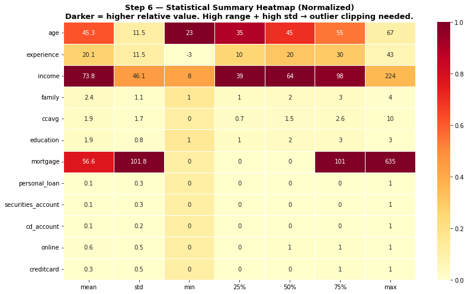

```python
desc = df.describe().T
desc['cv']    = (desc['std'] / desc['mean'].abs()).round(3)
desc['range'] = (desc['max'] - desc['min']).round(2)
print('Statistical Summary:'); display(desc.round(3))

cols_to_plot = ['mean', 'std', 'min', '25%', '50%', '75%', 'max']
heat_data = desc[cols_to_plot].apply(lambda x: (x - x.min()) / (x.max() - x.min() + 1e-9))

plt.figure(figsize=(12, 7))
sns.heatmap(heat_data, annot=desc[cols_to_plot].round(1),
            fmt='g', cmap='YlOrRd', linewidths=0.5, linecolor='white')
plt.title('Step 6 — Statistical Summary Heatmap (Normalized)\n'
          'Darker = higher relative value. High range + high std → outlier clipping needed.',
          fontweight='bold')
plt.tight_layout(); plt.show()
```

**💡 Pipeline decision:** High-range features (income, ccavg, mortgage) → IQR-based Clipper before scaling to prevent outliers distorting StandardScaler.

## Step 7 — Class Imbalance Analysis

**Why:** This is the most critical insight for model design. A model predicting 'No' for every customer achieves 90.4% accuracy with 0% recall on loan acceptors — completely useless for business.

**Business insight:** Imbalanced target is expected in banking. Loan acceptance is a rare event. This drives choice of F1-score and PR-AUC over accuracy.

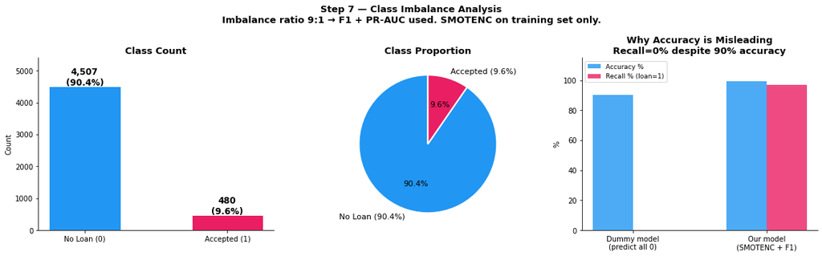

```
Imbalance ratio : 9.4:1
Dummy accuracy  : 90.4% with 0% recall on loan acceptors
```

```python
counts = df['personal_loan'].value_counts().sort_index()
pct    = df['personal_loan'].value_counts(normalize=True).sort_index() * 100

fig, axes = plt.subplots(1, 3, figsize=(16, 5))

bars = axes[0].bar(['No Loan (0)', 'Accepted (1)'], counts.values,
                   color=[BLUE, PINK], edgecolor='white', width=0.5)
for bar, v, p in zip(bars, counts.values, pct.values):
    axes[0].text(bar.get_x() + bar.get_width()/2, bar.get_height() + 30,
                 f'{v:,}\n({p:.1f}%)', ha='center', fontweight='bold', fontsize=12)
axes[0].set_title('Class Count'); axes[0].set_ylabel('Count')
axes[0].set_ylim(0, counts.max() * 1.2)

axes[1].pie(counts.values, labels=['No Loan (90.4%)', 'Accepted (9.6%)'],
            colors=[BLUE, PINK], startangle=90,
            wedgeprops={'edgecolor': 'white', 'linewidth': 2},
            autopct='%1.1f%%', textprops={'fontsize': 11})
axes[1].set_title('Class Proportion')

ratio     = counts[0] / counts[1]
dummy_acc = counts[0] / counts.sum() * 100
scenarios = ['Dummy model\n(predict all 0)', 'Our model\n(SMOTENC + F1)']
axes[2].bar(np.arange(2) - 0.15, [dummy_acc, 99.1], 0.3, label='Accuracy %', color=BLUE, alpha=0.8)
axes[2].bar(np.arange(2) + 0.15, [0, 96.9], 0.3, label='Recall % (loan=1)', color=PINK, alpha=0.8)
axes[2].set_xticks(np.arange(2)); axes[2].set_xticklabels(scenarios, fontsize=10)
axes[2].set_title('Why Accuracy is Misleading\nRecall=0% despite 90% accuracy')
axes[2].set_ylabel('%'); axes[2].legend(fontsize=9); axes[2].set_ylim(0, 115)

plt.suptitle(f'Step 7 — Class Imbalance Analysis\nImbalance ratio {ratio:.0f}:1 → F1 + PR-AUC used. SMOTENC on training set only.',
             fontsize=13, fontweight='bold')
plt.tight_layout(); plt.show()
print(f'Imbalance ratio : {ratio:.1f}:1')
print(f'Dummy accuracy  : {dummy_acc:.1f}% with 0% recall on loan acceptors')
```

**📌 Observation:** 9.4:1 imbalance. Third panel shows why accuracy is deceptive — dummy model scores 90.4% accuracy but catches zero loan acceptors.

**💡 Pipeline decision:** SMOTENC on training set only. F1-score as primary selection metric. PR-AUC, KS, and Brier score for comprehensive evaluation.

## Step 8 — Continuous Feature Distributions (Univariate)

**Why:** Distribution shape determines the right preprocessing. Normal → StandardScaler. Right-skewed → PowerTransformer first. This step directly motivates our dual preprocessor architecture.

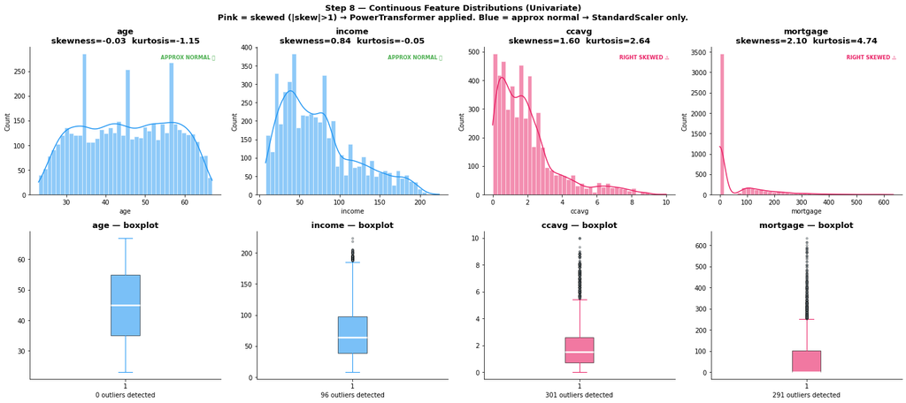

```python
cont_cols = ['age', 'income', 'ccavg', 'mortgage']
fig, axes = plt.subplots(2, 4, figsize=(20, 9))

for i, col in enumerate(cont_cols):
    skew = df[col].skew(); kurt = df[col].kurtosis()
    color = PINK if abs(skew) > 1 else BLUE
    sns.histplot(df[col], kde=True, bins=40, color=color, edgecolor='white', ax=axes[0, i])
    axes[0, i].set_title(f'{col}\nskewness={skew:.2f}  kurtosis={kurt:.2f}', fontweight='bold')
    skew_label = 'RIGHT SKEWED ⚠' if skew > 1 else 'LEFT SKEWED ⚠' if skew < -1 else 'APPROX NORMAL ✅'
    axes[0, i].text(0.97, 0.95, skew_label, transform=axes[0, i].transAxes,
                    ha='right', va='top', fontsize=8,
                    color=PINK if '⚠' in skew_label else GREEN, fontweight='bold')
    axes[1, i].boxplot(df[col].dropna(), patch_artist=True,
                       boxprops=dict(facecolor=color, alpha=0.6),
                       medianprops=dict(color='white', linewidth=2.5),
                       whiskerprops=dict(color=color), capprops=dict(color=color),
                       flierprops=dict(marker='o', markerfacecolor=GRAY, markersize=3, alpha=0.4))
    axes[1, i].set_title(f'{col} — boxplot')
    q1, q3 = df[col].quantile([0.25, 0.75])
    n_out  = ((df[col] < q1-1.5*(q3-q1)) | (df[col] > q3+1.5*(q3-q1))).sum()
    axes[1, i].set_xlabel(f'{n_out} outliers detected')

plt.suptitle('Step 8 — Continuous Feature Distributions (Univariate)\n'
             'Pink = skewed (|skew|>1) → PowerTransformer applied. Blue = approx normal → StandardScaler only.',
             fontsize=13, fontweight='bold')
plt.tight_layout(); plt.show()
```

**💡 Pipeline decision:** Skewed features → `PowerTransformer(yeo-johnson)` in scaled preprocessor for linear models. Tree models receive only Clipper-clipped raw values — scale/skew invariant.